# 2.2.matplotlib slides

## 2.2 Matplotlib

### Matplotlib

- https://matplotlib.org/
- Python 2D plotting library
- 다양한 그래프, 도표 표시
- 한 화면에 여러 이미지 표시

### Installation

- `pip install matplotlib`
- `sudo apt-get install python3-matplotlib`
- checking

```python
import matplotlib
matplotlib.__version__
```

```
'3.0.3'
```

### Module Import

```python
import matplotlib.pyplot as plt
```

### matplotlib magic command

실행 결과를 jupyter notebook 안에 삽입치켜서 보여준다.

```python
%matplotlib inline
```

### 배열로 그래프 그리기

- `plt.plot(a)`
  - x : 인덱스
  - y : 항목의 값

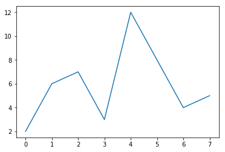

```python
import matplotlib.pyplot as plt
import numpy as np

a = np.array([2,6,7,3,12,8,4,5])    # 배열 생성
plt.plot(a)                         # plot 생성
plt.show()
```

### 두 배열로 그래프 그리기

- `plt.plot(x,y)`

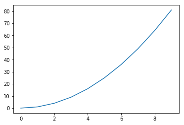

```python
import numpy as np

x = np.arange(10)
y = x ** 2
x, y
plt.plot(x,y)
plt.show()
```

# Color

- 색상 지정
  - `plt.plot(x,y,'r')

| charator | color |
| --- | --- |
| b | blue |
| g | green |
| r | red |
| c | cyan |
| m | magenta |
| y | yellow |
| k | black |
| w | white |

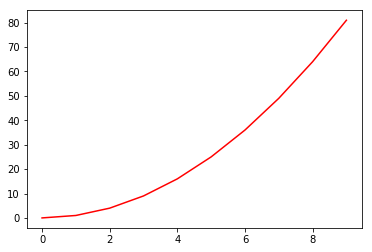

```python
import matplotlib.pyplot as plt
import numpy as np

x = np.arange(10)
y = x**2
plt.plot(x,y,'r')
plt.show()
```

# Line Style

- 선 스타일
- `plt.plot(x,y, '--g')

| charactor | style |
| --- | --- |
| - | solid (default) |
| -- | dashed |
| -. | dash-dot |
| : | dotted line |
| . | point maker |
| , | pixel marker |
| o | circle marker |
| v | triangle_down |
| ^ | triangle up |
| < | triangle left |
| > | triangle right |
| 1 | small tri down |
| 2 | small tri up |
| 3 | small tri left |
| 4 | small tri right |
| s | square |
| p | pentagon |
| * | start |
| h | hexagon |
| H | hexaong2 |
| + | plus |
| x | ex |
| D | diamond |
| d | thid diamond |
|  | vline |
| _ | Hline |

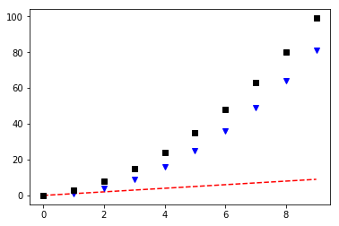

```python
x = np.arange(10)
f1 = x * 5
f2 = x **2
f3 = x **2 + x*2

plt.plot(x,'r--')   # 빨강색 이음선plt.plot(f1, 'g.')  # 초록색 점
plt.plot(f2, 'bv')  # 파랑색 역 삼각형
plt.plot(f3, 'ks' ) # 검정색 사각형
```

# Axis Label

- `plt.xlabel('str')`
- `plt.ylabel('str')`
- `plt.title('text')`

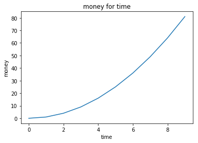

```python
import matplotlib.pyplot as plt
import numpy as np

x = np.arange(10)
y = x **2

plt.plot(x,y)
plt.xlabel('time')
plt.ylabel('money')
plt.title('money for time')
plt.show()
```

# Limitation

- 전체 데이타 중에 특정 영역만 표시
- `xlim(min,max)`
- `ylim(min, max)`

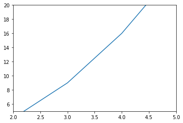

```python
import matplotlib.pyplot as plt
import numpy as np

x = np.arange(10)
y = x **2
plt.plot(x,y)
plt.xlim(2,5)
plt.ylim(5,20)
plt.show()
```

# Legend(범례)

- `plt.plot(x,y,'b', label='text')`
- `plt.legend(loc='str')`
  - upper left
  - upper center
  - upper right
  - center left
  - center
  - center right
  - lower left
  - lower center
  - lower right
  - best
  - right

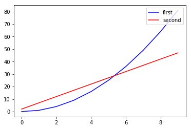

```python
import matplotlib.pyplot as plt
import numpy as np

x = np.arange(10)
y = x **2
y2 = x*5 + 2

plt.plot(x,y, 'b', label='first')
plt.plot(x,y2, 'r', label='second')
plt.legend(loc='upper right')
plt.show()
```

# Annotation

- annotate('str', xy=(x,y), xytest=(x,y), arrowprops={'color':'gree'}

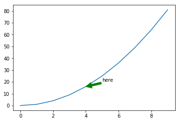

```python
import matplotlib.pyplot as plt
import numpy as np

x = np.arange(10)
y = x**2

plt.plot(x,y)
plt.annotate('here', xy=(4,16), xytext=(5,20), arrowprops={'color':'green'})
plt.show()
```

### Scatter

- `plt.scatter(x, y, s=None, c=None, market=None)`
- `plt.scatter(x,y, s=size, c='color', marker='style')`

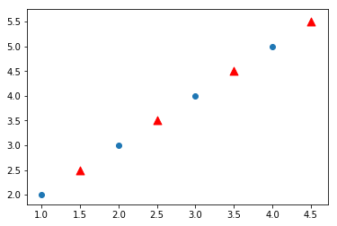

```python
x = np.arange(1,5)
y = np.arange(2, 6)
x2 = np.arange(1.5,5.5)
y2 = np.arange(2.5,6.5)
plt.scatter(x, y)
plt.scatter(x2, y2, s=80, c='r', marker='^')
plt.show()
```

# Subplot

- `plt.subplot(row, col, idx)` : 3개 숫자
- `plt.subplot(rci)` : 3자리 숫자

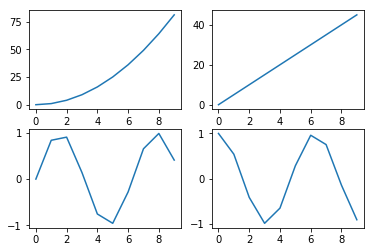

```python
import matplotlib.pyplot as plt
import numpy as np

x = np.arange(10)

plt.subplot(2,2,1)
plt.plot(x,x**2)
plt.subplot(2,2,2)
plt.plot(x,x*5)
plt.subplot(223)
plt.plot(x, np.sin(x))
plt.subplot(224)
plt.plot(x,np.cos(x))
plt.show()
```

# Fig Size

- plt.figure(figsize=(w,h))

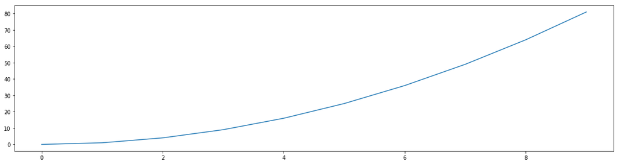

```python
import matplotlib.pyplot as plt
import numpy as np

x = np.arange(10)
y = x**2

plt.figure(figsize=(20,5))
plt.plot(x,y)
plt.show()
```

# Scatter

- plt.scatter(x,y)
- plt.scatter(x,y, s=size, c='color', marker='style')

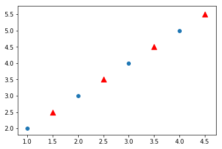

```python
import matplotlib.pyplot as plt
import numpy as np
x = np.arange(1,5)
y = np.arange(2, 6)
x2 = np.arange(1.5,5.5)
y2 = np.arange(2.5,6.5)
plt.scatter(x, y)
plt.scatter(x2, y2, s=80, c='r', marker='^')
plt.show()
```

# Image

- plt.imshow(img)
- OpenCV = GBR, Plot = RGB

[figure not shown]

```python
import cv2
from matplotlib import pyplot as plt

img = cv2.imread('./img/tkv.jpg')

plt.imshow(img) # 이미지 표시
plt.show()
```

### change BGR to RGB

- numpy slicing
- cv2.split(), cv2.merge()
- cv2.cvtColor(img, cv2.COLOR_BGR2RGB)

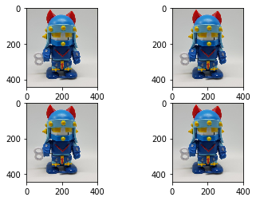

```python
img1 = cv2.imread('./img/tkv.jpg')
img2 = cv2.imread('./img/tkv.jpg')
img3 = cv2.imread('./img/tkv.jpg')
img4 = cv2.imread('./img/tkv.jpg')

img1_ = np.zeros_like(img1)
img1_[:,:,2],img1_[:,:,1], img1_[:,:,0] = img1[:,:,0],img1[:,:,1], img1[:,:,2]
img2 = img2[:,:, ::-1] # img1_rgb = img1[:,:,(2,1,0)]

b,g,r = cv2.split(img3)
img3 = cv2.merge([r,g,b])

img4 = cv2.cvtColor(img4, cv2.COLOR_BGR2RGB)
plt.subplot(2,2,1)
plt.imshow(img1_)
plt.subplot(2,2,2)
plt.imshow(img2)
plt.subplot(2,2,3)
plt.imshow(img3)
plt.subplot(2,2,4)
plt.imshow(img4)
```

### Histogram

- `plt.hist(img, bins, range)`

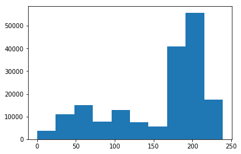

```python
img = cv2.imread('./img/tkv.jpg', cv2.IMREAD_GRAYSCALE)
plt.hist(img.ravel())
```